# Equality of Opportunity Seminar Paper

Data Science and Machine Learning 2187 & 2087

Leonard Fidlin, Daniel Jost, Anne Valder

14 1 2021

# **Research Question**

The selection of circumstances is a key aspect for an empirical analysis of inequality of opportunity, because estimates have been shown to be sensitive to the number of types considered (Brunori and Neidhoefer 2020).

# **Data**

Brunori and Neidhoefer (2020) choose the circumstances based on the data quality in their survey data. Opting for fewer missing entries in each category than other characteristics. In their German focused paper they use: sex, migration background, resident in either East or West Germany (not important for our Dutch sample), Father’s and Mother’s education and training, Father’s and Mother’s occupation measured by the ISCO code, number of siblings, and an indicator of dissability. Their sample is further restricted to ages 30-60. In their “original” EU-SILC data paper the use the following circumstances which we could find in the Dutch data:

General Household Information: Respondents sex (male, female) (GESLACHT), number of household members (AANTALHH), number of children in the household (AANTALKI), Highest level of education completed (OPLMET), primary occupation of the respondent (BEZIGHEI), type of accommodation (WONING).

Questionaire Household and Work: Marital Status (BURGST), Father/Mother main occupation/job (BRANCHE),

Total Gross Income Category (IJ161BR thru IJ16BR3), Total Net income of household (INKHH) Inheritance? If yes then: Inheritance of 100,000 or 500,000 should make sense: (HER2), (HER3)

Questionaire on Accommodation and mortgages: tenancy status (WO1)

What we dont have is migration status, number of working adults in households, managerial position of father/mother. Further we do not have indicators on the educational endowment of the parents of the questioned individuals.

# **Data Wrangling**

```r
library(rpart)
library(rpart.plot)
library(precrec)
library(caret)
library(party)
library(partykit)
library(tidyverse)
library(vcd)
library(RColorBrewer)
library(knitr)
library(glmnet)
library(haven)
library(fst)
library(ranger)
library(tuneRanger)
library(xgboost)
library(readr)
```

```r
# First we set the data path
data_path ="."

#loading the data
hhi2019 <- read_sav(file.path(data_path,"wetransfer-a0b059", "hhi2019en_1.0.sav"))
#hse2019 <- read_sav(file.path(data_path,"wetransfer-a0b059", "hse2019en_1.0.sav"))
wrk2019 <- read_sav(file.path(data_path,"wetransfer-a0b059", "wrk2019en_1.2.sav"))
inc2019 <- read_sav(file.path(data_path,"wetransfer-a0b059", "inc2019en_1.0.sav"))

#changing our files from SPSS files into CSV files.
write_csv(x = hhi2019, path = "hhi2019.csv" )
hhi2019csv <- read.csv(file.path(data_path, "hhi2019.csv"))

write_csv(x = inc2019, path = "inc2019.csv" )
inc2019csv <- read.csv(file.path(data_path, "inc2019.csv"))

write_csv(x = wrk2019, path = "wrk2019.csv" )
wrk2019csv <- read.csv(file.path(data_path, "wrk2019.csv"))

# Creating subsamples of the datasets containing only the variables we will need.

sub_wrk2019csv <- wrk2019csv %>% select(c(nohhold,burgst, branche))
sub_inc2019csv <- inc2019csv %>% select(c(nohhold, ij161, in50, in49a))

# Joining the data to the general information on the household dataset

join <- hhi2019csv %>% left_join(sub_wrk2019csv, by ="nohhold")
netherlands_survey_data <- join %>%  left_join(sub_inc2019csv, by = "nohhold")

# First look at our data
summary(netherlands_survey_data) %>% head()
```

```
##     nohhold          nomem           gebjaar        geslacht
##  Min.   :    6   Min.   : 1.000   Min.   :1925   Min.   :1.000
##  1st Qu.:24512   1st Qu.: 1.000   1st Qu.:1956   1st Qu.:1.000
##  Median :45267   Median : 2.000   Median :1972   Median :2.000
##  Mean   :46030   Mean   : 2.192   Mean   :1975   Mean   :1.504
##  3rd Qu.:67057   3rd Qu.: 3.000   3rd Qu.:1994   3rd Qu.:2.000
##  Max.   :89986   Max.   :10.000   Max.   :2019   Max.   :2.000
##     positie          oplzon          oplmet         bezighei
##  Min.   :1.000   Min.   :1.000   Min.   :1.000   Min.   : 0.000
##  1st Qu.:1.000   1st Qu.:3.000   1st Qu.:3.000   1st Qu.: 1.000
##  Median :2.000   Median :5.000   Median :5.000   Median : 6.000
##  Mean   :2.614   Mean   :4.882   Mean   :4.886   Mean   : 5.035
##  3rd Qu.:5.000   3rd Qu.:6.000   3rd Qu.:6.000   3rd Qu.: 8.000
##  Max.   :7.000   Max.   :9.000   Max.   :9.000   Max.   :13.000
##     aantalhh        aantalki          sted           regio
##  Min.   :1.000   Min.   :0.000   Min.   :1.000   Min.   :1.000
##  1st Qu.:2.000   1st Qu.:0.000   1st Qu.:2.000   1st Qu.:2.000
##  Median :3.000   Median :1.000   Median :3.000   Median :3.000
##  Mean   :3.237   Mean   :1.245   Mean   :3.192   Mean   :3.219
##  3rd Qu.:4.000   3rd Qu.:2.000   3rd Qu.:4.000   3rd Qu.:4.000
##  Max.   :8.000   Max.   :6.000   Max.   :5.000   Max.   :5.000
##       prov          woonvorm        account          kostwin
##  Min.   :20.00   Min.   :1.000   Min.   :0.0000   Min.   :0.0000
##  1st Qu.:25.00   1st Qu.:2.000   1st Qu.:0.0000   1st Qu.:0.0000
##  Median :27.00   Median :3.000   Median :0.0000   Median :0.0000
##  Mean   :26.51   Mean   :2.681   Mean   :0.3909   Mean   :0.3908
##  3rd Qu.:29.00   3rd Qu.:3.000   3rd Qu.:1.0000   3rd Qu.:1.0000
##  Max.   :31.00   Max.   :5.000   Max.   :1.0000   Max.   :1.0000
##     partner           woning          burgst         branche
##  Min.   :0.0000   Min.   :1.000   Min.   :1.000   Min.   : 1.000
##  1st Qu.:1.0000   1st Qu.:1.000   1st Qu.:1.000   1st Qu.: 6.000
##  Median :1.0000   Median :1.000   Median :1.000   Median :11.000
##  Mean   :0.8744   Mean   :1.239   Mean   :2.459   Mean   : 9.793
##  3rd Qu.:1.0000   3rd Qu.:1.000   3rd Qu.:4.000   3rd Qu.:13.000
##  Max.   :1.0000   Max.   :4.000   Max.   :6.000   Max.   :15.000
##      ij161             in50            in49a
##  Min.   :     0   Min.   : 1.000   Min.   :     0
##  1st Qu.: 12500   1st Qu.: 7.000   1st Qu.: 24000
##  Median : 33000   Median : 8.000   Median : 38000
##  Mean   : 35643   Mean   : 7.464   Mean   : 40851
##  3rd Qu.: 51000   3rd Qu.: 9.000   3rd Qu.: 52000
##  Max.   :211000   Max.   :11.000   Max.   :510000
```

```r
# We decide to drop the NAs
sum(is.na(netherlands_survey_data$in50))
```

```
## [1] 6620
```

```r
netherlands_survey_clean <- netherlands_survey_data %>% as_data_frame()  %>% drop_na(in50)
netherlands_survey_clean_2 <- netherlands_survey_data %>% as_data_frame() %>% drop_na(in49a)

# mutation and renaming of some of our exxplanatory variables

netherlands_survey_clean <- netherlands_survey_clean %>% mutate(
                    #drop_na(in49a),
                    #income_K = (in50/1000),
                    age = as.numeric(2019 - gebjaar),
                    income  = as.factor(in50),
                     income_K = (in49a/1000)) %>%
                    rename(
                          "household_ID" = nohhold,
                          "birthyear" = gebjaar,
                          "gender" = geslacht,
                          "educ" = oplmet,
                          "occupation" = bezighei,
                          "num_hhold_memb" = aantalhh,
                          "num_hhold_children" = aantalki,
                          "urbanization" =  sted,
                          "region"= regio,
                          "hhold_type" = woonvorm,
                          "tenancy" = woning,
                          "industry" = branche)

summary(netherlands_survey_clean) %>% head()
```

```
##   household_ID       nomem         birthyear        gender         positie
##  Min.   :  106   Min.   :1.000   Min.   :1925   Min.   :1.000   Min.   :1.000
##  1st Qu.:26187   1st Qu.:1.000   1st Qu.:1958   1st Qu.:1.000   1st Qu.:1.000
##  Median :45917   Median :2.000   Median :1974   Median :2.000   Median :2.000
##  Mean   :46627   Mean   :2.139   Mean   :1976   Mean   :1.506   Mean   :2.557
##  3rd Qu.:68544   3rd Qu.:3.000   3rd Qu.:1994   3rd Qu.:2.000   3rd Qu.:5.000
##  Max.   :89972   Max.   :9.000   Max.   :2019   Max.   :2.000   Max.   :7.000
##      oplzon           educ         occupation     num_hhold_memb
##  Min.   :1.000   Min.   :1.000   Min.   : 0.000   Min.   :1.000
##  1st Qu.:3.000   1st Qu.:3.000   1st Qu.: 1.000   1st Qu.:2.000
##  Median :5.000   Median :5.000   Median : 6.000   Median :3.000
##  Mean   :4.819   Mean   :4.894   Mean   : 4.855   Mean   :3.173
##  3rd Qu.:6.000   3rd Qu.:6.000   3rd Qu.: 8.000   3rd Qu.:4.000
##  Max.   :9.000   Max.   :9.000   Max.   :13.000   Max.   :7.000
##  num_hhold_children  urbanization       region           prov
##  Min.   :0.000      Min.   :1.000   Min.   :1.000   Min.   :20.00
##  1st Qu.:0.000      1st Qu.:2.000   1st Qu.:2.000   1st Qu.:24.00
##  Median :1.000      Median :3.000   Median :3.000   Median :27.00
##  Mean   :1.184      Mean   :3.248   Mean   :3.122   Mean   :26.16
##  3rd Qu.:2.000      3rd Qu.:4.000   3rd Qu.:4.000   3rd Qu.:28.00
##  Max.   :5.000      Max.   :5.000   Max.   :5.000   Max.   :31.00
##    hhold_type       account          kostwin          partner
##  Min.   :1.000   Min.   :0.0000   Min.   :0.0000   Min.   :0.0000
##  1st Qu.:2.000   1st Qu.:0.0000   1st Qu.:0.0000   1st Qu.:1.0000
##  Median :3.000   Median :0.0000   Median :0.0000   Median :1.0000
##  Mean   :2.626   Mean   :0.3965   Mean   :0.3967   Mean   :0.8919
##  3rd Qu.:3.000   3rd Qu.:1.0000   3rd Qu.:1.0000   3rd Qu.:1.0000
##  Max.   :5.000   Max.   :1.0000   Max.   :1.0000   Max.   :1.0000
##     tenancy          burgst         industry         ij161
##  Min.   :1.000   Min.   :1.000   Min.   : 1.00   Min.   :     9
##  1st Qu.:1.000   1st Qu.:1.000   1st Qu.: 6.00   1st Qu.: 15286
##  Median :1.000   Median :1.000   Median :11.00   Median : 33500
##  Mean   :1.273   Mean   :2.376   Mean   :10.08   Mean   : 35742
##  3rd Qu.:2.000   3rd Qu.:4.000   3rd Qu.:13.00   3rd Qu.: 50000
##  Max.   :4.000   Max.   :6.000   Max.   :15.00   Max.   :211000
##       in50            in49a          age            income        income_K
##  Min.   : 1.000   Min.   : NA   Min.   : 0.00   8      :1365   Min.   : NA
##  1st Qu.: 7.000   1st Qu.: NA   1st Qu.:25.00   9      :1076   1st Qu.: NA
##  Median : 8.000   Median : NA   Median :45.00   10     : 637   Median : NA
##  Mean   : 7.464   Mean   :NaN   Mean   :43.21   7      : 592   Mean   :NaN
##  3rd Qu.: 9.000   3rd Qu.: NA   3rd Qu.:61.00   6      : 352   3rd Qu.: NA
##  Max.   :11.000   Max.   : NA   Max.   :94.00   1      : 349   Max.   : NA
```

```r
# changing to "readable" classes
levels(netherlands_survey_clean$income)
```

```
##  [1] "1"  "2"  "3"  "4"  "5"  "6"  "7"  "8"  "9"  "10" "11"
```

```r
levels(netherlands_survey_clean$income) <- c("first_class", "second_class", "third_class", "fourth_class", "fifth_class", "sixth_class", "seventh_class", "eigth_class", "ninth_class", "tenth_class", "eleventh_class" )

# different income variable for ctree
netherlands_survey_clean2 <- netherlands_survey_clean_2 %>% mutate(
                    age = as.numeric(2019 - gebjaar),
                     income_K = (in49a/1000)) %>%
                    rename(
                          "household_ID" = nohhold,
                          "birthyear" = gebjaar,
                          "gender" = geslacht,
                          "educ" = oplmet,
                          "occupation" = bezighei,
                          "num_hhold_memb" = aantalhh,
                          "num_hhold_children" = aantalki,
                          "urbanization" =  sted,
                          "region"= regio,
                          "hhold_type" = woonvorm,
                          "tenancy" = woning,
                          "industry" = branche)
```

# **Decision tree**

First we manually try to estimate a simple decion tree.

```r
set.seed(123)

netherlands_survey_clean <- netherlands_survey_clean %>%
  mutate(train_index = sample(c("train", "test"), nrow(netherlands_survey_clean), replace=TRUE, prob=c(0.85, 0.15)))

train <- netherlands_survey_clean %>% filter(train_index=="train")
test <- netherlands_survey_clean %>% filter(train_index=="test")


netherlands_survey_clean2 <- netherlands_survey_clean2 %>%
  mutate(train_index = sample(c("train", "test"), nrow(netherlands_survey_clean2), replace=TRUE, prob=c(0.85, 0.15)))

train2 <- netherlands_survey_clean2 %>% filter(train_index=="train")
test2 <- netherlands_survey_clean2 %>% filter(train_index=="test")
```

```r
formula <- income  ~ gender + educ + occupation  + num_hhold_children +  urbanization + region + hhold_type + tenancy + industry + age

tree <- rpart(formula, data = train, cp=.01)
tree
```

```
## n= 4273
##
## node), split, n, loss, yval, (yprob)
##       * denotes terminal node
##
##  1) root 4273 3105 eigth_class (0.07 0.017 0.015 0.026 0.034 0.07 0.12 0.27 0.22 0.13 0.036)
##    2) tenancy>=1.5 1129  876 eigth_class (0.11 0.05 0.031 0.067 0.071 0.16 0.18 0.22 0.093 0.018 0)
##      4) num_hhold_children>=4.5 66   33 first_class (0.5 0.5 0 0 0 0 0 0 0 0 0) *
##      5) num_hhold_children< 4.5 1063  810 eigth_class (0.082 0.023 0.033 0.071 0.075 0.17 0.19 0.24 0.099 0.019 0) *
##    3) tenancy< 1.5 3144 2229 eigth_class (0.057 0.0048 0.0089 0.011 0.021 0.039 0.093 0.29 0.26 0.17 0.049)
##      6) age>=60.5 755  482 eigth_class (0.048 0.011 0.011 0.021 0.057 0.061 0.16 0.36 0.15 0.07 0.048) *
##      7) age< 60.5 2389 1683 ninth_class (0.06 0.0029 0.0084 0.008 0.01 0.032 0.07 0.27 0.3 0.2 0.049)
##       14) educ< 6.5 1828 1259 ninth_class (0.063 0.0033 0.0082 0.01 0.0088 0.031 0.076 0.29 0.31 0.16 0.039) *
##       15) educ>=6.5 561  390 tenth_class (0.05 0.0018 0.0089 0 0.014 0.036 0.052 0.21 0.24 0.3 0.08)
##         30) educ>=7.5 369  252 ninth_class (0.051 0.0027 0.011 0 0.014 0.043 0.041 0.24 0.32 0.23 0.051) *
##         31) educ< 7.5 192  106 tenth_class (0.047 0 0.0052 0 0.016 0.021 0.073 0.15 0.1 0.45 0.14) *
```

# **Decision tree plot**

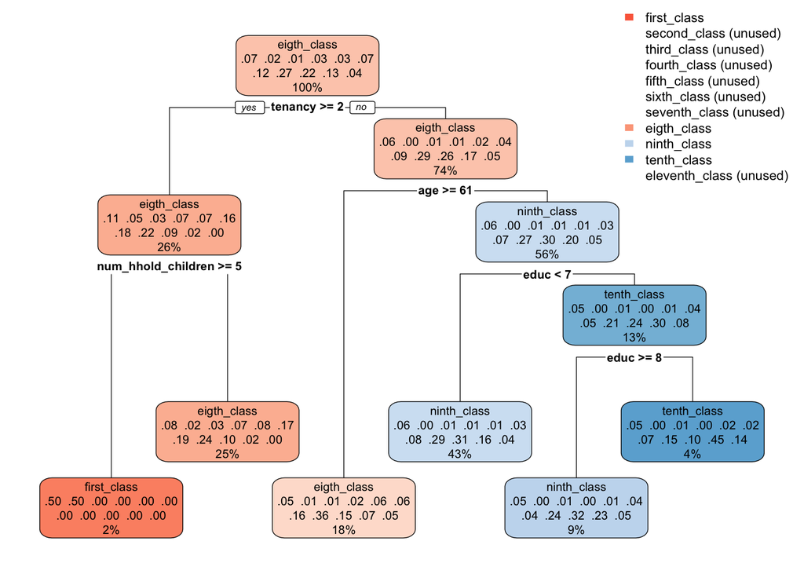

```r
rpart.plot(tree,box.palette="RdBu", nn=FALSE, type=2)
```

# **Decision tree confusion matrix**

```r
test$prediction_tree <- predict(tree, newdata = test, type = c("class"))

class(test$prediction_tree)
```

```
## [1] "factor"
```

```r
levels(test$prediction_tree)
```

```
##  [1] "first_class"    "second_class"   "third_class"    "fourth_class"
##  [5] "fifth_class"    "sixth_class"    "seventh_class"  "eigth_class"
##  [9] "ninth_class"    "tenth_class"    "eleventh_class"
```

```r
confusion <- confusionMatrix(test$income, test$prediction_tree, mode="sens_spec")
confusion
```

```
## Confusion Matrix and Statistics
##
##                 Reference
## Prediction       first_class second_class third_class fourth_class fifth_class
##   first_class              2            0           0            0           0
##   second_class             2            0           0            0           0
##   third_class              0            0           0            0           0
##   fourth_class             0            0           0            0           0
##   fifth_class              0            0           0            0           0
##   sixth_class              0            0           0            0           0
##   seventh_class            0            0           0            0           0
##   eigth_class              0            0           0            0           0
##   ninth_class              0            0           0            0           0
##   tenth_class              0            0           0            0           0
##   eleventh_class           0            0           0            0           0
##                 Reference
## Prediction       sixth_class seventh_class eigth_class ninth_class tenth_class
##   first_class              0             0          24          20           4
##   second_class             0             0           1           1           0
##   third_class              0             0           6           1           0
##   fourth_class             0             0          15           5           0
##   fifth_class              0             0          16           3           1
##   sixth_class              0             0          31          20           0
##   seventh_class            0             0          66          27           3
##   eigth_class              0             0          91         103           3
##   ninth_class              0             0          38         109           5
##   tenth_class              0             0          18          64          16
##   eleventh_class           0             0           5          19           4
##                 Reference
## Prediction       eleventh_class
##   first_class                 0
##   second_class                0
##   third_class                 0
##   fourth_class                0
##   fifth_class                 0
##   sixth_class                 0
##   seventh_class               0
##   eigth_class                 0
##   ninth_class                 0
##   tenth_class                 0
```

[output cut: 36 more lines]

```
## Pos Pred Value                         NA             0.4619             0.7171
## Neg Pred Value                         NA             0.5817             0.5394
## Prevalence                         0.0000             0.4302             0.5145
## Detection Rate                     0.0000             0.1259             0.1508
## Detection Prevalence               0.1328             0.2725             0.2102
## Balanced Accuracy                      NA             0.5177             0.5853
##                      Class: tenth_class Class: eleventh_class
## Sensitivity                     0.44444                    NA
## Specificity                     0.88064               0.96127
## Pos Pred Value                  0.16327                    NA
## Neg Pred Value                  0.96800                    NA
## Prevalence                      0.04979               0.00000
## Detection Rate                  0.02213               0.00000
## Detection Prevalence            0.13555               0.03873
## Balanced Accuracy               0.66254                    NA
```

# **Decision tree caret**

```r
control <- trainControl(method = "repeatedcv", number = 10, repeats = 10, savePredictions = T, classProbs = T, summaryFunction = multiClassSummary)

tuning_grid <- expand.grid(cp = seq(0, 0.02, by= 0.001))
tuning_grid
```

```
##       cp
## 1  0.000
## 2  0.001
## 3  0.002
## 4  0.003
## 5  0.004
## 6  0.005
## 7  0.006
## 8  0.007
## 9  0.008
## 10 0.009
## 11 0.010
## 12 0.011
## 13 0.012
## 14 0.013
## 15 0.014
## 16 0.015
## 17 0.016
## 18 0.017
## 19 0.018
## 20 0.019
## 21 0.020
```

```r
tree_caret <- caret::train(data = netherlands_survey_clean, formula , method = "rpart", trControl = control, tuneGrid = tuning_grid, metric = "Acuracy", na.action = na.pass)
tree_caret
```

```
## CART
##
## 4996 samples
##   10 predictor
##   11 classes: 'first_class', 'second_class', 'third_class', 'fourth_class', 'fifth_class', 'sixth_class', 'seventh_class', 'eigth_class', 'ninth_class', 'tenth_class', 'eleventh_class'
##
## No pre-processing
## Resampling: Cross-Validated (10 fold, repeated 10 times)
## Summary of sample sizes: 4494, 4498, 4496, 4495, 4494, 4495, ...
## Resampling results across tuning parameters:
##
##   cp     logLoss   AUC        prAUC         Accuracy   Kappa          Mean_F1
##   0.000  4.517344  0.7960030  0.2831881421  0.4011596   2.681474e-01  0.2882122
##   0.001  2.437278  0.7959577  0.2522334085  0.4112532   2.655457e-01  0.3049482
##   0.002  1.916834  0.7582319  0.2035376708  0.3704952   1.975611e-01        NaN
##   0.003  1.842789  0.7263698  0.1636916820  0.3417715   1.491117e-01        NaN
##   0.004  1.843671  0.7132321  0.1494773275  0.3336649   1.344818e-01        NaN
##   0.005  1.844267  0.7108221  0.1457963617  0.3312829   1.311040e-01        NaN
##   0.006  1.849843  0.7071355  0.1362963261  0.3271823   1.244237e-01        NaN
##   0.007  1.854805  0.7031624  0.1269255531  0.3182762   1.104762e-01        NaN
##   0.008  1.866572  0.6933278  0.1026185125  0.3011008   8.339451e-02        NaN
##   0.009  1.872909  0.6854258  0.0877624380  0.2942512   7.223498e-02        NaN
##   0.010  1.912438  0.6501921  0.0622093690  0.2856653   4.914406e-02        NaN
##   0.011  1.940678  0.6207844  0.0436656629  0.2819427   3.542677e-02        NaN
##   0.012  1.961004  0.5924975  0.0328663590  0.2803841   2.581724e-02        NaN
##   0.013  1.987714  0.5533412  0.0183198289  0.2750396   1.224990e-02        NaN
##   0.014  2.008322  0.5243928  0.0081800494  0.2727582   3.994410e-03        NaN
##   0.015  2.021339  0.5069627  0.0023859482  0.2725183   4.462367e-04        NaN
##   0.016  2.024821  0.5018850  0.0005955567  0.2729584  -6.124488e-06        NaN
##   0.017  2.026092  0.5000000  0.0000000000  0.2732195   0.000000e+00        NaN
##   0.018  2.026092  0.5000000  0.0000000000  0.2732195   0.000000e+00        NaN
##   0.019  2.026092  0.5000000  0.0000000000  0.2732195   0.000000e+00        NaN
##   0.020  2.026092  0.5000000  0.0000000000  0.2732195   0.000000e+00        NaN
##   Mean_Sensitivity  Mean_Specificity  Mean_Pos_Pred_Value  Mean_Neg_Pred_Value
##   0.26712281        0.9333128         0.2992341            0.9340753
##   0.25155646        0.9327204         0.3540569            0.9343845
##   0.19865030        0.9264363               NaN            0.9287396
##   0.16892167        0.9221211               NaN            0.9245750
##   0.16040140        0.9208035               NaN            0.9233744
##   0.15856746        0.9205062               NaN            0.9231875
```

[output cut: 25 more lines]

```
##         NaN       0.13019829   0.02675011           0.5227793
##         NaN       0.11005144   0.02596957           0.5117079
##         NaN       0.10246041   0.02563115           0.5073166
##         NaN       0.09907209   0.02548946           0.5052059
##         NaN       0.09486699   0.02500360           0.5025076
##         NaN       0.09228061   0.02479620           0.5008541
##         NaN       0.09111041   0.02477439           0.5001170
##         NaN       0.09092329   0.02481440           0.5000060
##         NaN       0.09090909   0.02483814           0.5000000
##         NaN       0.09090909   0.02483814           0.5000000
##         NaN       0.09090909   0.02483814           0.5000000
##         NaN       0.09090909   0.02483814           0.5000000
##
## logLoss was used to select the optimal model using the smallest value.
## The final value used for the model was cp = 0.003.
```

# **Decision tree caret Confusion matrix**

```r
test$prediction_tree_caret <- predict.train(tree_caret, newdata = test, type = c("raw"), na.action = na.rpart)

levels(test$prediction_tree_caret)
```

```
##  [1] "first_class"    "second_class"   "third_class"    "fourth_class"
##  [5] "fifth_class"    "sixth_class"    "seventh_class"  "eigth_class"
##  [9] "ninth_class"    "tenth_class"    "eleventh_class"
```

```r
class(test$prediction_tree_caret)
```

```
## [1] "factor"
```

```r
confusion2 <- confusionMatrix(test$income, test$prediction_tree_caret, mode="sens_spec")
confusion2
```

```
## Confusion Matrix and Statistics
##
##                 Reference
## Prediction       first_class second_class third_class fourth_class fifth_class
##   first_class              3            0           0            0           0
##   second_class             2            0           0            0           0
##   third_class              0            0           0            0           0
##   fourth_class             0            0           0            0           0
##   fifth_class              0            0           0            0           0
##   sixth_class              0            0           0            0           0
##   seventh_class            0            0           0            0           0
##   eigth_class              0            0           0            0           0
##   ninth_class              0            0           0            0           0
##   tenth_class              0            0           0            0           0
##   eleventh_class           0            0           0            0           0
##                 Reference
## Prediction       sixth_class seventh_class eigth_class ninth_class tenth_class
##   first_class              2             2          23          19           1
##   second_class             0             0           2           0           0
##   third_class              0             0           7           0           0
##   fourth_class             1             2          16           1           0
##   fifth_class              0             3          16           1           0
##   sixth_class              4             2          35          10           0
##   seventh_class            1             5          76          11           3
##   eigth_class              1             4         126          53          13
##   ninth_class              0             0          67          79           6
##   tenth_class              0             1          33          41          23
##   eleventh_class           0             0           6          19           3
##                 Reference
## Prediction       eleventh_class
##   first_class                 0
##   second_class                0
##   third_class                 0
##   fourth_class                0
##   fifth_class                 0
##   sixth_class                 0
##   seventh_class               0
##   eigth_class                 0
##   ninth_class                 0
##   tenth_class                 0
```

[output cut: 36 more lines]

```
## Pos Pred Value                   0.052083             0.6396             0.5197
## Neg Pred Value                   0.977671             0.4658             0.7285
## Prevalence                       0.026279             0.5629             0.3237
## Detection Rate                   0.006916             0.1743             0.1093
## Detection Prevalence             0.132780             0.2725             0.2102
## Balanced Accuracy                0.566948             0.5424             0.5942
##                      Class: tenth_class Class: eleventh_class
## Sensitivity                     0.46939                    NA
## Specificity                     0.88872               0.96127
## Pos Pred Value                  0.23469                    NA
## Neg Pred Value                  0.95840                    NA
## Prevalence                      0.06777               0.00000
## Detection Rate                  0.03181               0.00000
## Detection Prevalence            0.13555               0.03873
## Balanced Accuracy               0.67906                    NA
```

# **Decision tree caret plot 1**

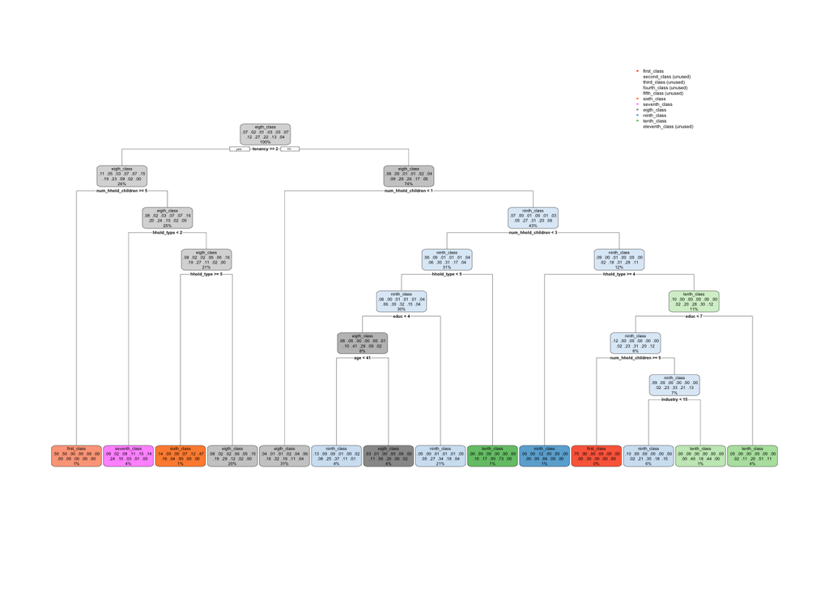

```r
tree_caret_final <- tree_caret$finalModel
rpart.plot(tree_caret_final, nn=FALSE, type=2)
```

# **Decision tree caret plot 1**

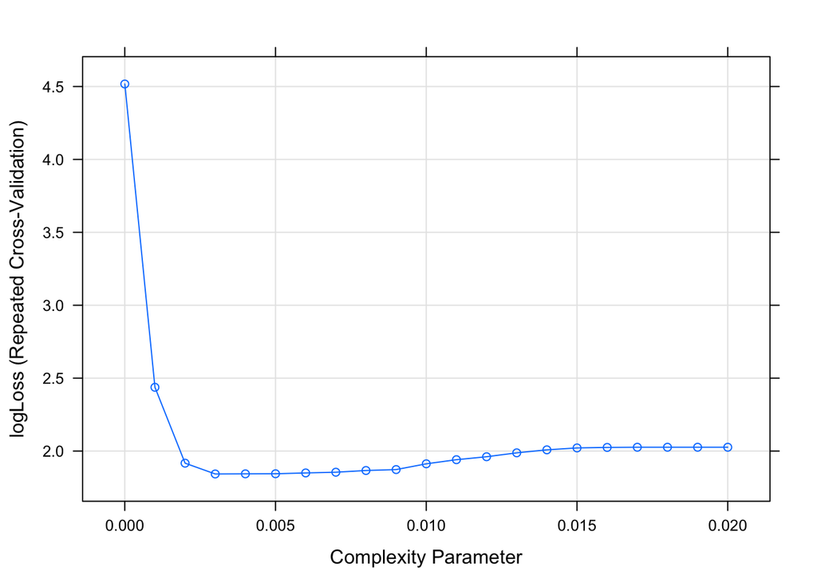

```r
plot(tree_caret)
```

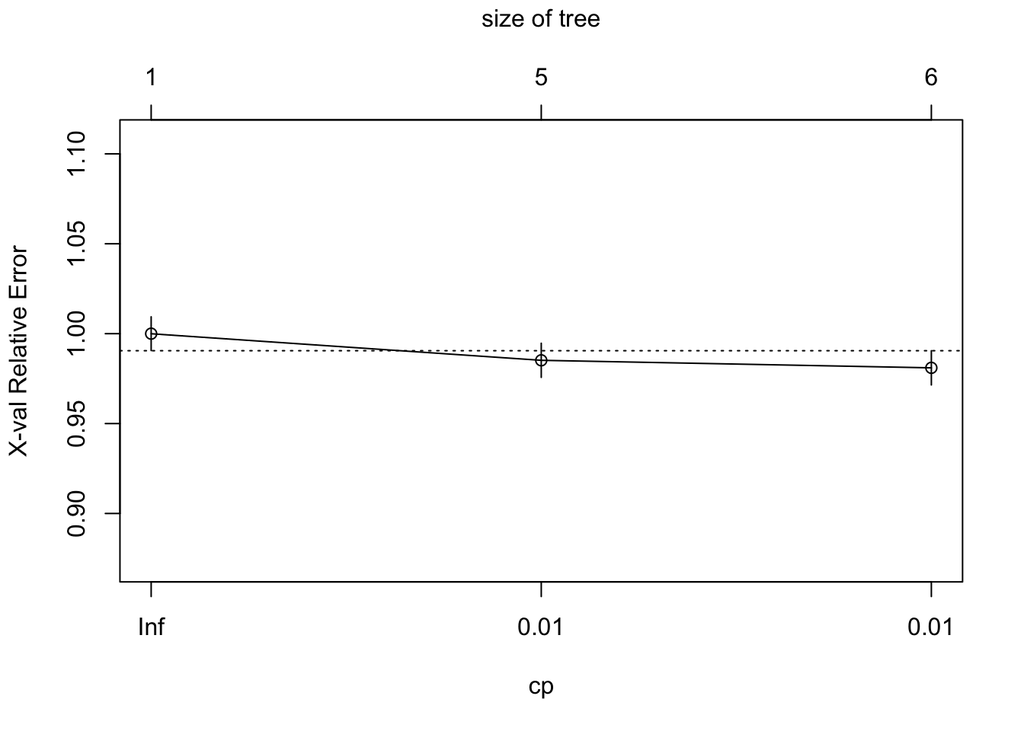

```r
plotcp(tree)
```

# **Method**: Conditional Inference Trees

- `ctree` from party package in R
- recursive partitioning just like `rpart`
- `rpart`: maximizing an information measure
- `ctree`: significance test procedure

### Advantages

**Advantages of Trees:** straightforward to interpret

**Advantages of Trees over linear regression models:** very large set of observations can be used & model speciﬁcation is no longer exogenously given

**Advantages of Conditional Inference Trees over Regression and Classification Trees (CART):** the algorithm automatically provides a test for the null hypothesis of equality of opportunity & prevents overfitting while CART “cannot distinguish between a significant and an insignificant improvement in the information measure” (Mingers 1987, as cited in Torsten Hothorn (n.d.), 2) & consider the distributional properties of the measures.

### Procedure

The algorithm follows a stepwise procedure (Brunori and Neidhoefer 2020, 7–8):

1. **Choose confidence level**
2. **Choose feature:** test all the null hypotheses of independence between the individual outcome and each of all the observable circumstances
   1. no hypothesis can be rejected: stop
   2. one or more circumstance is siginificant: select the circumstance with the smallest p-value and proceed
3. **Choose split:** for every possible way the selected circumstance can divide the sample into two subgroups, test the hypothesis of same mean outcome in the two resulting subgroups. Choose the splitting point with the smallest p-value
4. **Repeat :)**

# **Conditional inference tree**

```r
formula2 <- income_K  ~ gender + educ + occupation  + num_hhold_children +  urbanization + region + hhold_type + tenancy + industry + age

Ctree <- ctree(formula2, data = train2)
Ctree
```

```
##
## Model formula:
## income_K ~ gender + educ + occupation + num_hhold_children +
##     urbanization + region + hhold_type + tenancy + industry +
##     age
##
## Fitted party:
## [1] root
## |   [2] tenancy <= 1
## |   |   [3] age <= 56
## |   |   |   [4] urbanization <= 2
## |   |   |   |   [5] hhold_type <= 2
## |   |   |   |   |   [6] educ <= 5: 38.232 (n = 77, err = 27114.6)
## |   |   |   |   |   [7] educ > 5
## |   |   |   |   |   |   [8] region <= 1: 65.318 (n = 34, err = 53966.0)
## |   |   |   |   |   |   [9] region > 1: 42.351 (n = 55, err = 21452.8)
## |   |   |   |   [10] hhold_type > 2: 56.121 (n = 413, err = 567223.2)
## |   |   |   [11] urbanization > 2
## |   |   |   |   [12] educ <= 5
## |   |   |   |   |   [13] region <= 2
## |   |   |   |   |   |   [14] num_hhold_children <= 0: 33.322 (n = 52, err = 12164.5)
## |   |   |   |   |   |   [15] num_hhold_children > 0
## |   |   |   |   |   |   |   [16] urbanization <= 3
## |   |   |   |   |   |   |   |   [17] industry <= 6: 51.571 (n = 10, err = 1531.8)
## |   |   |   |   |   |   |   |   [18] industry > 6: 44.852 (n = 38, err = 21896.5)
## |   |   |   |   |   |   |   [19] urbanization > 3: 55.576 (n = 106, err = 131281.7)
## |   |   |   |   |   [20] region > 2
## |   |   |   |   |   |   [21] urbanization <= 3
## |   |   |   |   |   |   |   [22] industry <= 3: 77.554 (n = 12, err = 78010.4)
## |   |   |   |   |   |   |   [23] industry > 3: 47.848 (n = 72, err = 30199.6)
## |   |   |   |   |   |   [24] urbanization > 3
## |   |   |   |   |   |   |   [25] num_hhold_children <= 3
## |   |   |   |   |   |   |   |   [26] region <= 3
## |   |   |   |   |   |   |   |   |   [27] urbanization <= 4: 28.277 (n = 57, err = 16268.6)
## |   |   |   |   |   |   |   |   |   [28] urbanization > 4: 50.123 (n = 49, err = 103039.2)
## |   |   |   |   |   |   |   |   [29] region > 3: 50.886 (n = 140, err = 281610.7)
## |   |   |   |   |   |   |   [30] num_hhold_children > 3: 16.526 (n = 34, err = 2616.2)
## |   |   |   |   [31] educ > 5: 50.938 (n = 546, err = 400656.3)
## |   |   [32] age > 56
## |   |   |   [33] educ <= 3: 30.255 (n = 537, err = 417257.1)
## |   |   |   [34] educ > 3: 42.754 (n = 814, err = 1128565.4)
## |   [35] tenancy > 1: 25.291 (n = 667, err = 417231.4)
##
## Number of inner nodes:    17
## Number of terminal nodes: 18
```

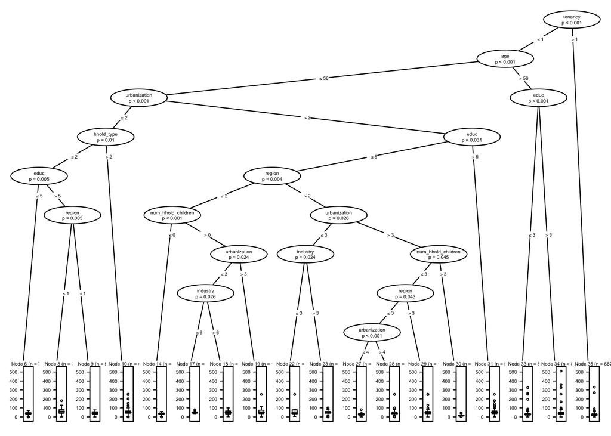

```r
plot(Ctree, gp = gpar(fontsize = 4),
  inner_panel=node_inner,
  ip_args=list(id = FALSE))
```

```r
test2$prediction_Ctree <- predict(Ctree, newdata = test2, type = c())

test2$prediction_Ctree <- as.factor(test2$prediction_Ctree)
test2$income_K <- as.factor(test2$income_K)

class(test2$income_K)
```

```
## [1] "factor"
```

```r
class(test2$prediction_Ctree)
```

```
## [1] "factor"
```

```r
#confusionR <- confusionMatrix(test2$income_K, test2$prediction_Ctree, mode="sens_spec")
#confusionR
```

# **References**

Brunori, Paolo, and Guido Neidhoefer. 2020. “The Evolution of Inequality of Opportunity in Germany: A Machine Learning Approach.” SERIES 01-2020. Dipartimento di Economia e Finanza - Università degli Studi di Bari "Aldo Moro". http://www.seriesworkingpapers.it/RePEc/bai/series/SERIES_WP_01-2020.pdf.

Torsten Hothorn, Achim Zeileis, Kurt Hornik. n.d. “Ctree: Conditional Inference Trees: R Vignette.” https://cran.r-project.org/web/packages/partykit/vignettes/ctree.pdf.